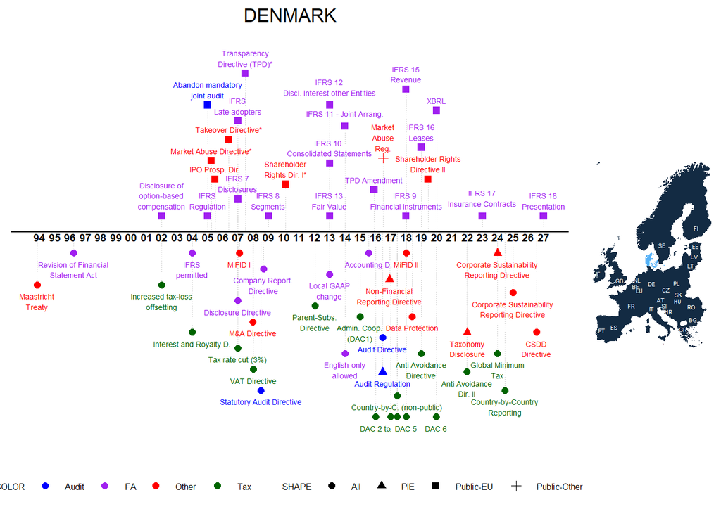

Notes: The graph depicts major regulatory changes that we identified via an extensive literature search, an online survey of mentioned authors, and other sources. Please note that the graph does not include all possible regulatory changes, e.g. minor revisions to local GAAP or tax rate changes below 3% are not included. The dates of EU Directives are based on the official transposition deadlines unless denoted with a *, in which case we included the entry-to-force date as identified in the literature. For more information, please go to [Labro and Pierk (2023)](http://www.eu-regulations.com/Labro_Pierk_2023.pdf). We kindly ask that you cite the paper if you use the information on this website in your research project. Do you have comments or see anything missing? Please email us!

## Regulations, Publications, Further Graphs

The tab ‘Regulations’ includes links to the regulations, gives short descriptions, and provides selective papers for further reading. If the regulation is a national transposition of an EU Directive, the link to the Directive is given. The tab ‘Number of Regulations’ shows graphically the number of regulations 8 years around the respective year (-4,-3,-2,-1,0,+1,+2,+3). The tab ‘Number of Categories” shows graphically the number of different categories 8 years around the respective year (-4,-3,-2,-1,0,+1,+2,+3). The tab ’Publications’ shows all publications that include the countries’ names and variations thereof in the title, abstract, or keywords. Similarly, the tab ‘SSRN’ shows papers of the SSRN Accouning Research Network that include the countries’ names and variations.

### Regulations

[output not shown]

[output cut: 50 more lines]

### Number of Regulations

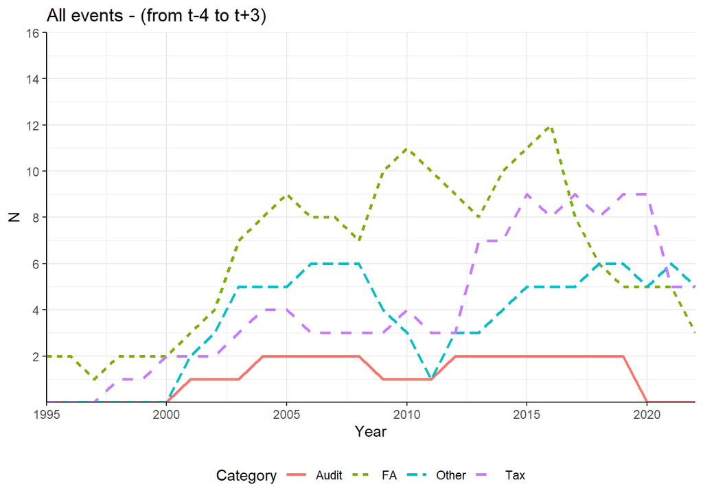

### Number of Categories

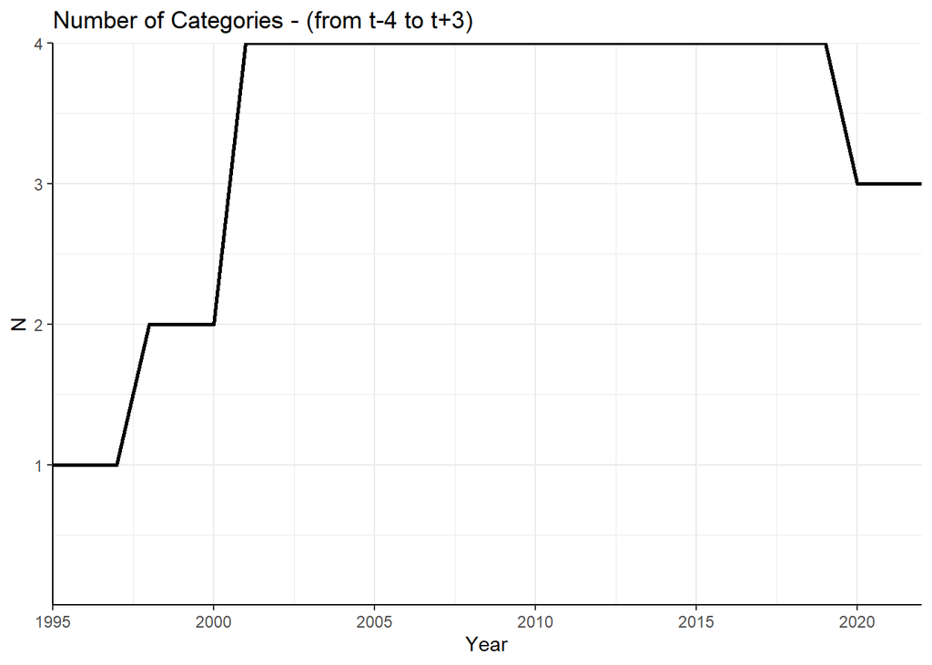

### Publications

|  | authors | title | year | journal |
| --- | --- | --- | --- | --- |
| 1 | Kacanski S., Lusher D., Wang P. | auditor selection process: an interplay of demand mechanisms–a multilevel network approach | 2021 | European Accounting Review |
| 2 | Nørreklit H., Trenca M. | performance management in a milieu of customer participatory measurement: beyond the ratings and rankings of strictly come dancing | 2021 | British Accounting Review |
| 3 | Rikhardsson P., Rohde C., Christensen L., Batt C.E. | management controls and crisis: evidence from the banking sector | 2021 | Accounting, Auditing and Accountability Journal |
| 4 | Søgaard J.S. | a blockchain-enabled platform for vat settlement | 2021 | International Journal of Accounting Information Systems |
| 5 | Girdhar S., Jeppesen K.K. | practice variation in big-4 transparency reports | 2018 | Accounting, Auditing and Accountability Journal |
| 6 | Holm C., Thinggaard F. | from joint to single audits–audit quality differences and auditor pairings | 2018 | Accounting and Business Research |
| 7 | Johansen T.R., Plenborg T. | company responses to demands for annual report changes | 2018 | Accounting, Auditing and Accountability Journal |
| 8 | Lesage C., Ratzinger-Sakel N.V.S., Kettunen J. | consequences of the abandonment of mandatory joint audit: an empirical study of audit costs and audit quality effects | 2017 | European Accounting Review |
| 9 | Nielsen C., Roslender R., Schaper S. | explaining the demise of the intellectual capital statement in denmark | 2017 | Accounting, Auditing and Accountability Journal |
| 10 | Roslender R., Nielsen C. | lessons for progressing narrative reporting: learning from the experience of disseminating the danish intellectual capital statement approach | 2017 | Accounting Forum |

[output cut: 35 more lines]

### SSRN

|  | authors | title | Posted | Revised |
| --- | --- | --- | --- | --- |
| 1 | Peter Koerver Schmidt, Jacob Graff Nielsen and Helle Vogt | how taxation shaped danish history | 2021-12-06 |  |
| 2 | Qazi Awais Amin | firms cash management, adjustment cost and its impact on firms’ speed of adjustment: a cross country analysis | 2021-11-18 |  |
| 3 | Per Nikolaj Bukh, Karina Skovvang Christensen and Anne Kirstine Svanholt | making sense of cost-consciousness in social work | 2020-12-31 | 2021-01-03 |
| 4 | Ricardo Garcia Anton and Ricardo Garcia Anton | testing the maturity of eu corporate tax law: a principle-based legislation in the eu context? | 2020-12-01 |  |
| 5 | Jinyan Li, Nathan Jin Bao, Sean Shanghua Hu and Matias Zerbino | tax weapons in the covid-19 war: a preliminary study of brazil, canada, denmark, uk and us | 2020-08-11 |  |
| 6 | Rikke Holmslykke Kristensen, Pamela Kent, Bent Warming‐Rasmussen and Carolyn Windsor | do mother and father auditors have equal prospects for career advancement? | 2020-05-22 |  |
| 7 | Daisy Ogembo and Vili Lehdonvirta | taxing earnings from the platform economy: an eu digital single window for income data? | 2020-05-21 |  |
| 8 | Slobodan Kacanski, Dean Lusher and Peng Wang | auditor selection process: an interplay of demand mechanisms – a multilevel network approach | 2020-03-31 |  |